# Numerical Methods for PDEs (Spring 2017), Lab 10

Gustav Delius, Richard Southwell

# Wave equation

In this lab we will code an explicit and an implicit method to solve the wave equation.
$$\frac{\partial^{2} u}{\partial t^{2}}(x,t) - \alpha^{2}\frac{\partial^{2} u}{\partial
x^{2}}(x,t)=F(x,t),$$
For $a<x< b$ and $0<t<T$, subject to the boundary conditions
$$u(a, t) = u(b, t)=0 \quad \hbox{for} \quad t\in[0,T]$$
and initial conditions
$$u(x, 0) = f(x), ~~~
\frac{\partial u}{\partial t}(x,0)=g(x) \quad \hbox{for} \quad x\in[a,b],$$
where $f(x)$ and $g(x)$ are given functions.

## Explicit method

```r
explicitWave <- function(F=function(x, t) 0*x, f=function(x) 0*x, g=function(x) 0*x,
                         alpha=1, a=0, b=1, N=30, T=1, M=30) {
    # set up space grid
    h <- (b-a)/N
    x <- a + h*(1:(N-1))
    xLong <- c(a, x, b)  # includes the endpoints

    # set up time grid
    tau <- T/M
    t <- tau*(0:M)

    # Set up evolution matrix eq.(4.10)
    gs <- (alpha*tau/h)^2
    A <- diag(2-2*gs, N-1)
    for (k in 1:(N-2)) {
        A[k,k+1] <- gs
        A[k+1,k] <- gs
    }

    w <- matrix(0, N-1, M+1)  # Matrix to hold the solution

    # Initial conditions
    w[, 1] <- f(x)  # Initial value
    fpp <- (f(x-h) -2*f(x) + f(x+h))/h^2  # Approximate derivative of f
    w[, 2] <- f(x) + tau*g(x) + tau^2/2*(alpha^2*fpp + F(x,0))  # eq.(4.14)

    # Loop over time steps
    for (j in 2:M) {
        # Use eq.(4.9)
        w[, j+1] <- A %*% w[, j] - w[, j-1] + tau^2 * F(x, t[j])
    }

    # Return a list consisting of time grid, x grid and solution
    return(list(x=xLong, t=t, w=rbind(0, w, 0)))
}
```

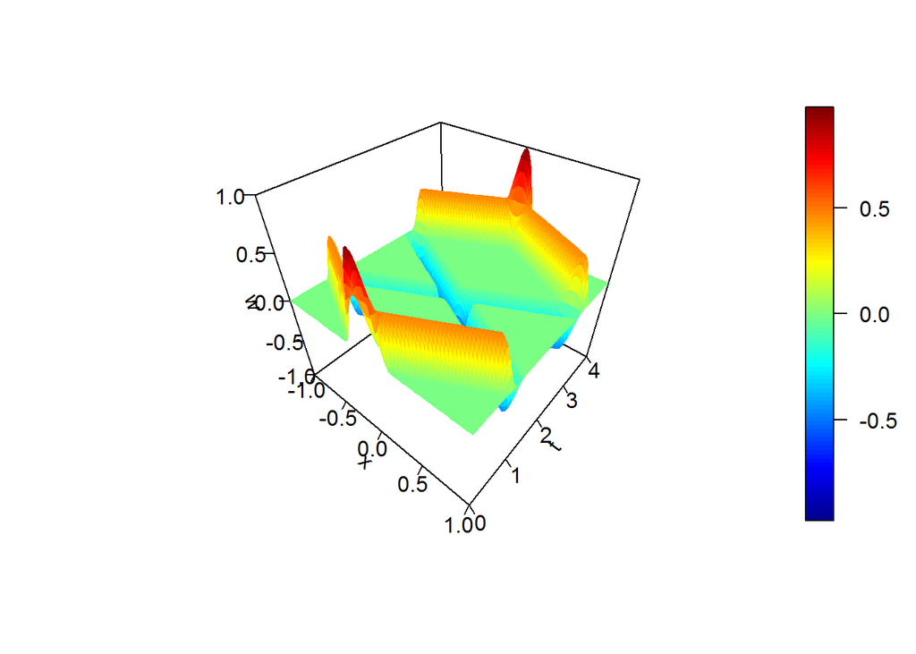

```r
sol <- explicitWave(f=function(x) ifelse(abs(x)<1/4, (1+cos(4*pi*x))/2, 0),
                    a=-1, N=80, T=4, M=160)
library("plot3Drgl")
persp3D(sol$x, sol$t, sol$w,
        xlab="x", ylab="t", zlab="w",
        ticktype="detailed", nticks=4)
```

```r
plotrgl(smooth=TRUE, lighting = TRUE)
```

### Exercise 1

Similarly solve the homogeneous wave equation with boundary condition
$$u(x,0)=f(x)=\begin{cases}(1+\cos(4\pi x))/2 & \text{ if }|x|<1/4\\
0& \text{ otherwise }\end{cases},\\
\frac{\partial u}{\partial t}(x,0)
=g(x)=\begin{cases}2\pi\sin(4\pi x) & \text{ if }|x|<1/4\\
0& \text{ otherwise }\end{cases}.$$

### Exercise 2

Similarly solve the homogeneous wave equation with boundary condition
$$u(x,0)=f(x)=\begin{cases}\sin(4\pi x)/2 & \text{ if }|x|<1/4\\
0& \text{ otherwise }\end{cases},\\
\frac{\partial u}{\partial t}(x,0)
=g(x)=\begin{cases}-2\cos(4\pi x) & \text{ if }|x|<1/4\\
0& \text{ otherwise }\end{cases}.$$

### Exercise 3

Now solve the same problem but with twice the resolution in the time direction, i.e., with $M=320$ steps instead of $M=160$. Keep the number of steps in the x direction at $N=80$. Take a close look at the 3d plot of the solution. What do you observe? Can you explain this?

### Exercise 4

Next solve the same problem but with twice the resolution in the x direction, but with the old resolution of $M=160$ in the time direction. What do you observe? Does this agree with your expectation?

## Implicit method

To avoid stability problems we can use the implicit method described in the notes in eq.(4.15). This requires the solution of a system of linear equations at each time step. When we restrict ourselves to the wave equation with constant wave speed, the matrices involved do not change between time steps and therefore it is most efficient to use matrix inversion. This is coded up in the following function:

```r
implicitWave <- function(F=function(x, t) 0*x,
                         f=function(x) 0*x, g=function(x) 0*x,
                         alpha=1, a=0, b=1, N=30, T=1, M=30, sigma=0.5) {
    # set up space grid
    h <- (b-a)/N
    x <- a + h*(1:(N-1))
    xLong <- c(a, x, b)  # includes the endpoints

    # set up time grid
    tau <- T/M
    t <- tau*(0:M)

    # Set up matrices
    gs <- (alpha*tau/h)^2
    A <- diag(1+2*sigma*gs, N-1)
    B <- diag(2-2*(1-2*sigma)*gs, N-1)
    C <- diag(-1-2*sigma*gs, N-1)
    for (k in 1:(N-2)) {
        A[k,k+1] <- -sigma*gs
        A[k+1,k] <- -sigma*gs
        B[k,k+1] <- (1-2*sigma)*gs
        B[k+1,k] <- (1-2*sigma)*gs
        C[k,k+1] <- sigma*gs
        C[k+1,k] <- sigma*gs
    }
    Ainv <- solve(A)
    AinvB <- Ainv %*% B
    AinvC <- Ainv %*% C

    w <- matrix(0, N-1, M+1)  # Matrix to hold the solution

    # Initial conditions
    w[, 1] <- f(x)  # Initial value
    fpp <- (f(x-h) -2*f(x) + f(x+h))/h^2  # Approximate derivative of f
    w[, 2] <- f(x) + tau*g(x) + tau^2/2*(alpha^2*fpp + F(x,0))  # eq.(4.14)

    # Loop over time steps
    for (j in 2:M) {
        w[, j+1] <- AinvB %*% w[, j] +AinvC %*% w[, j-1] + tau^2 * Ainv %*% F(x, t[j])
    }

    # Return a list consisting of time grid, x grid and solution
    return(list(x=xLong, t=t, w=rbind(0, w, 0)))
}
```

Note that we added the parameter $\sigma$ to the parameters of the function so that we can experiment easily with different values.

## On your own

### Exercise 6

Experiment with adding inhomogenous terms to the wave equation.

### Exercise 7

Modify the methods to allow variable wave speed and experiment.